# Gráficos estadísticos

Eduardo Marín Nicolalde

eduardo.marin@taryanalytics.com

# 1. Histogramas

Un histograma nos permite representar un conjunto de datos numéricos, con barras (juntas), una vez que los hemos agrupado en intervalos o categorías.

Tomamos un conjunto de datos numéricos x, 20 valores numéricos que agruparemos en cinco intervalos de manera arbitraria.

```r
x = c(6.9, 6.2, 5.4, 4.7, 4.8, 6.0, 6.3, 5.0, 4.5, 6.3,
      5.9, 6.7, 6.1, 5.0, 6.7, 5.8, 6.1, 5.7, 5.2, 4.6)
x
```

1. 6.9

2. 6.2

3. 5.4

4. 4.7

5. 4.8

6. 6

7. 6.3

8. 5

9. 4.5

10. 6.3

11. 5.9

12. 6.7

13. 6.1

14. 5

15. 6.7

16. 5.8

17. 6.1

18. 5.7

19. 5.2

20. 4.6

Ejecutamos el comando `hist` sobre nuestro conjunto x:

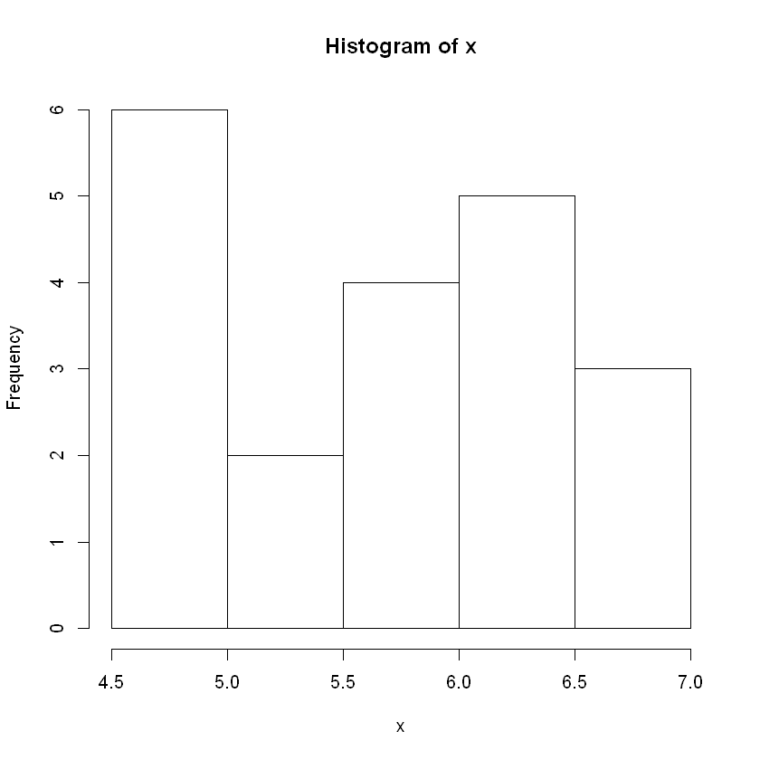

```r
hist(x)
```

Este gráfico consta de barras cuya altura (eje y) es el número de elementos perteneciente a cada uno de los intervalos (eje x). El número de elementos en el eje y se indica como **Frecuency** y corresponde a la frecuencia absoluta.

En R, los intervalos para los histogramas se calculan usando uno de los siguientes métodos: **Sturges**, **Scott** o **Freedman-Diaconis** que veremos a continuación:

## Sturges

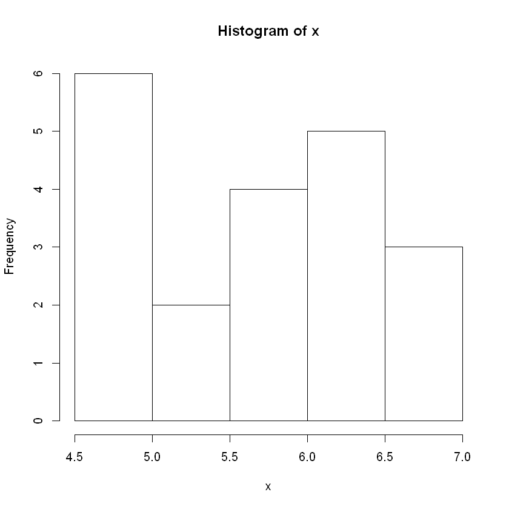

```r
hist(x, breaks = "Sturges")
```

## **Scott**

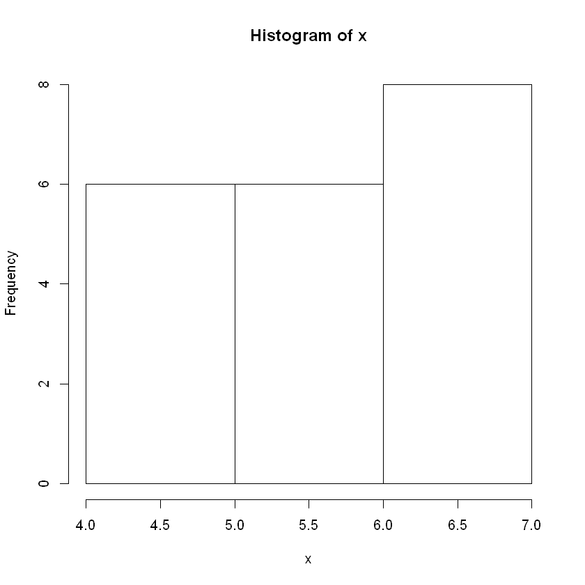

```r
hist(x, breaks = "Scott")
```

## Freedman-Diaconis

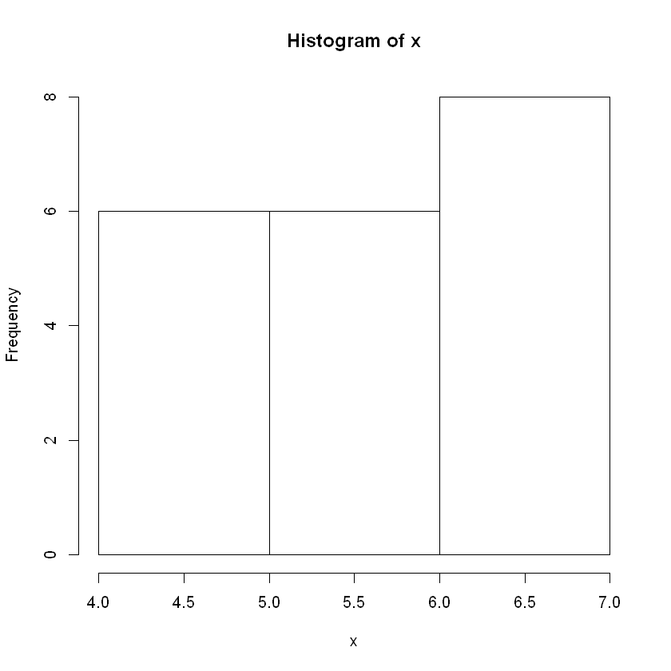

```r
hist(x, breaks = "FD")
```

# Colores

Para adicionar colores a los gráficos podemos usar el argumento **col** indicando, entre comillas y en inglés el nombre del color; es posible ver la lista de colores aplicando el comando **colors()** en la consola de R o en el siguiente pdf http://www.stat.columbia.edu/~tzheng/files/Rcolor.pdf

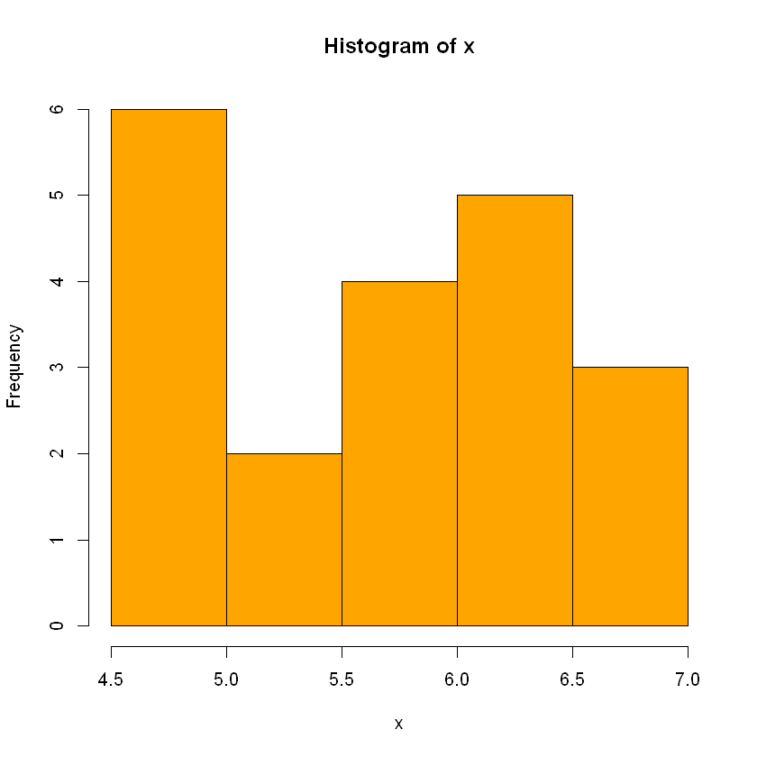

```r
hist(x, col = "orange")
```

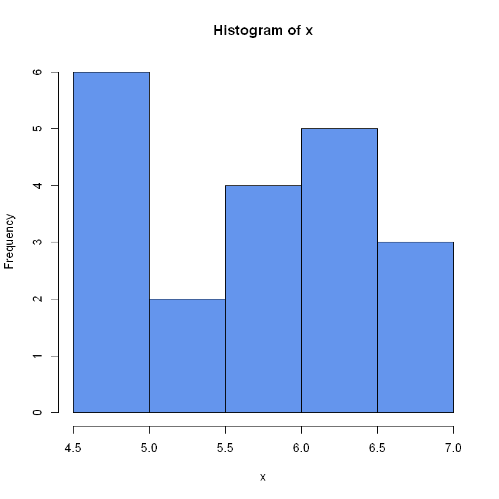

```r
hist(x, col = "cornflowerblue")
```

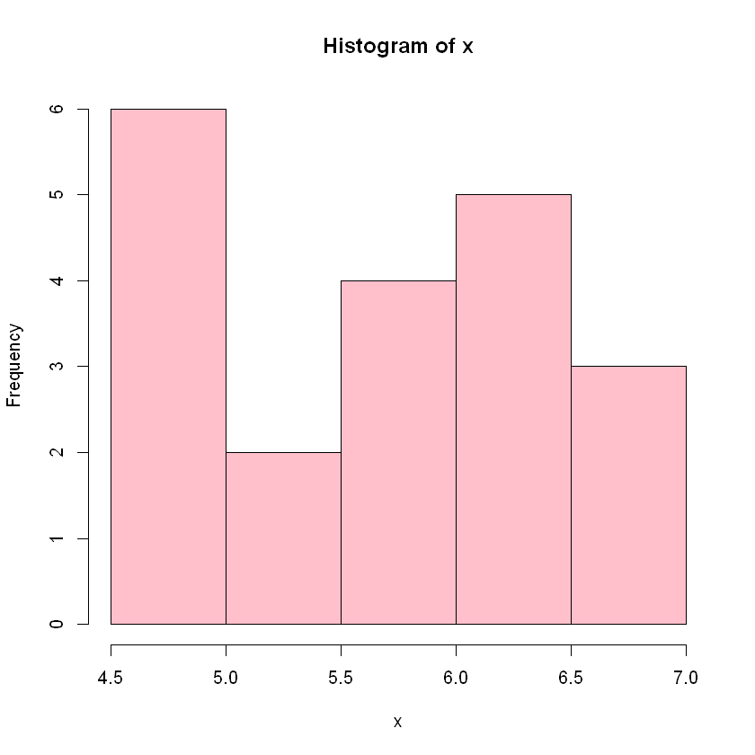

```r
hist(x, col = "pink")
```

# Etiquetas

Es posible usar los argumentos **main**, **xlab** e **ylab** para modificar el título y el nombre de los ejes:

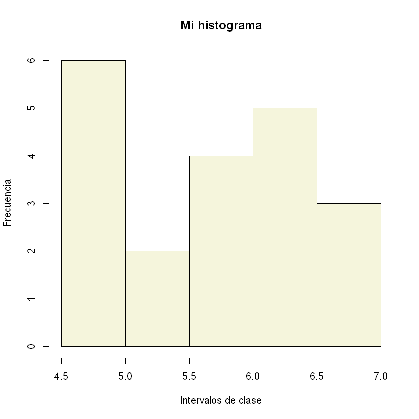

```r
hist(x, col = "beige", main = "Mi histograma",
     xlab = "Intervalos de clase", ylab = "Frecuencia")
```

# Bar charts

Para ver lo diagramas de barras (barplots), usaremos tablas de contingencia (conteo) o tablas de frecuencia relativa (proporción). La base de datos **mtcars** viene precargada en R. Más información en https://stat.ethz.ch/R-manual/R-devel/library/datasets/html/mtcars.html

```r
prop.table(table(mtcars$gear))
table(mtcars$gear)
```

```
      3       4       5
0.46875 0.37500 0.15625
```

```
 3  4  5
15 12  5
```

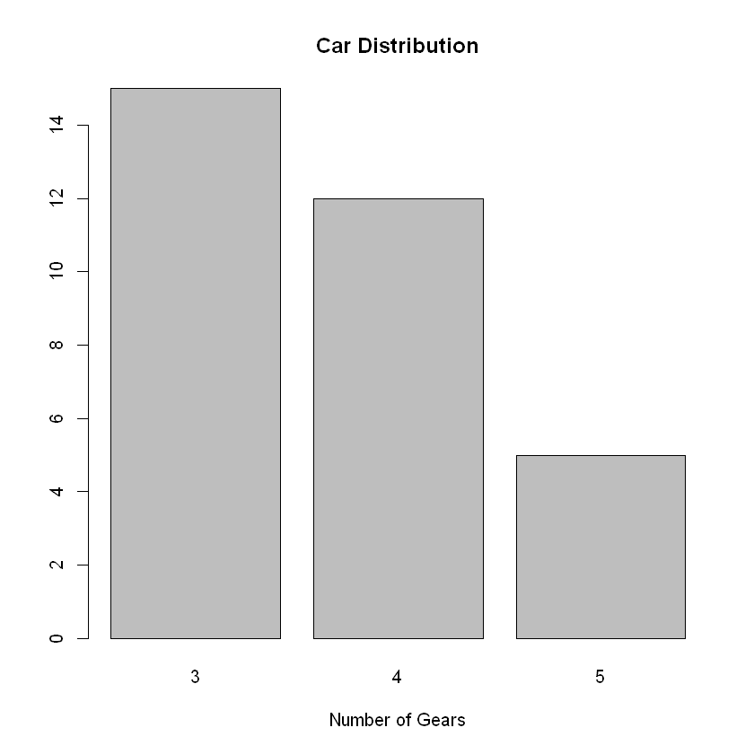

```r
barplot(table(mtcars$gear), main="Car Distribution", xlab="Number of Gears")
```

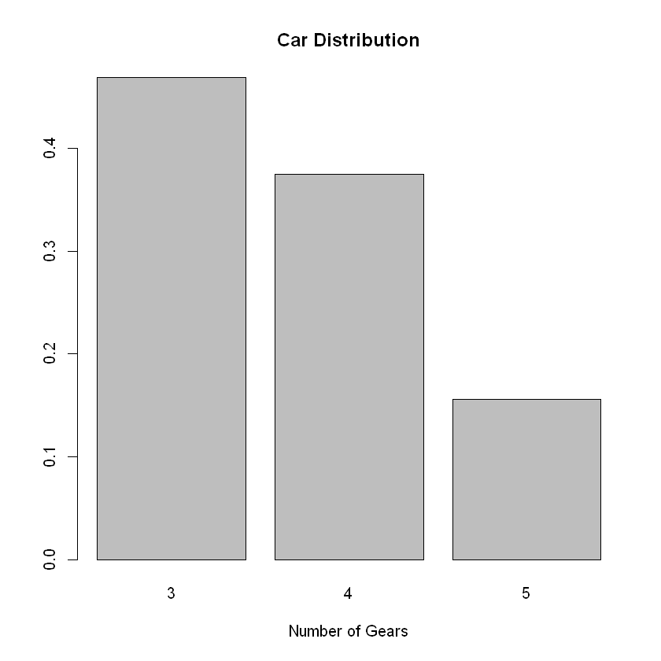

```r
barplot(prop.table(table(mtcars$gear)), main="Car Distribution", xlab="Number of Gears")
```

## Barras horizontales y etiquetas

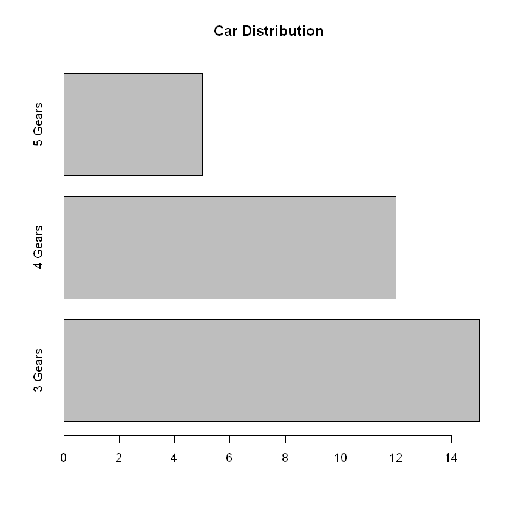

```r
barplot(table(mtcars$gear), main="Car Distribution", horiz=TRUE,
  names.arg=c("3 Gears", "4 Gears", "5 Gears"))
```

## Barras apiladas

```r
counts = table(mtcars$vs, mtcars$gear)
counts
```

```
     3  4  5
  0 12  2  4
  1  3 10  1
```

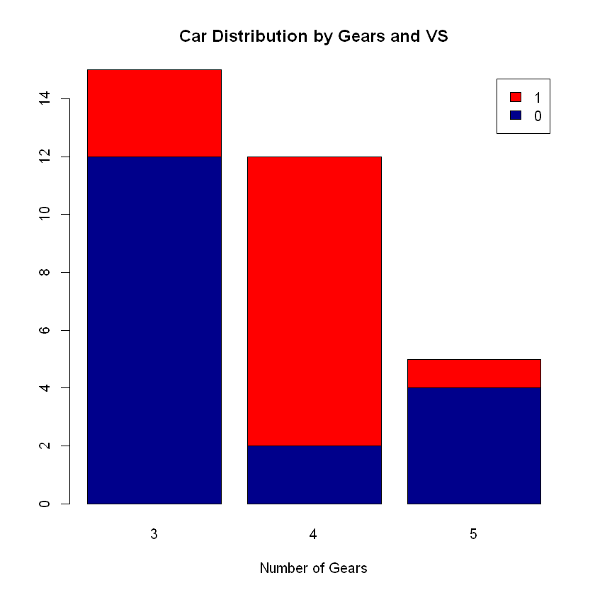

```r
barplot(counts, main = "Car Distribution by Gears and VS",
        xlab = "Number of Gears", col=c("darkblue","red"),
        legend = rownames(counts))
```

## Barras agrupadas

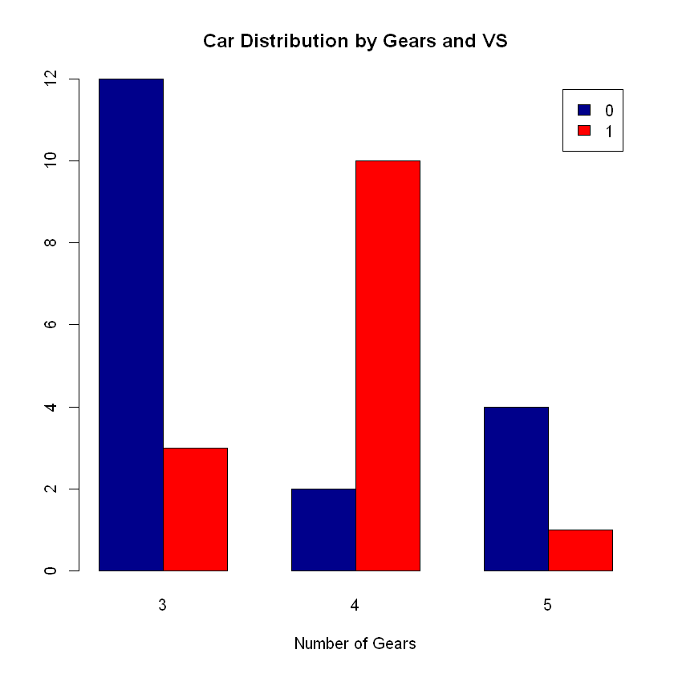

```r
barplot(counts, main="Car Distribution by Gears and VS",
  xlab="Number of Gears", col=c("darkblue","red"),
  legend = rownames(counts), beside=TRUE)
```

# Scatterplots

Hay muchas maneras de crear un scatterplot en R. la función básica es **plot(x, y)**, donde x y y son vectores numéricos.

`plot(x, y, main, xlab, ylab, xlim, ylim, axes)`

**x** es el conjunto de datos cuyos valores son las coordenadas horizontales; **y** es el conjunto de datos cuyos valores son las coordenadas verticales; **main** es el título de la gráfica; **xlab** es la etiqueta en el eje horizontal; **ylab** es la etiqueta en el eje vertical; **xlim** es de los límites de los valores de x utilizados para el trazado; **ylim** es de los límites de los valores de y utilizados para el trazado; **axes** indica si ambos ejes deben graficarse.

```r
input = mtcars[,c('wt','mpg')]
head(input)
```

|  | wt | mpg |
| --- | --- | --- |
| Mazda RX4 | 2.620 | 21.0 |
| Mazda RX4 Wag | 2.875 | 21.0 |
| Datsun 710 | 2.320 | 22.8 |
| Hornet 4 Drive | 3.215 | 21.4 |
| Hornet Sportabout | 3.440 | 18.7 |
| Valiant | 3.460 | 18.1 |

Con estos datos crear un scatterplot de la relación entre el wt (peso) y mpg (millas por galón):

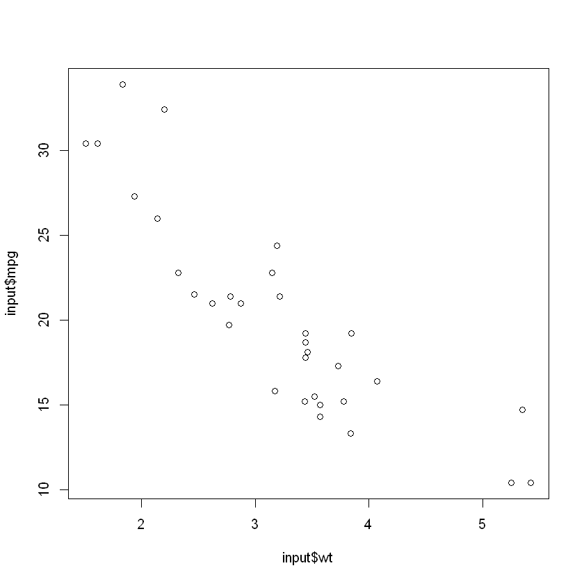

```r
plot(x = input$wt,y = input$mpg)
```

Grafique la tabla para automóviles con un peso entre 2.5 a 5 y un millaje entre 15 y 30.

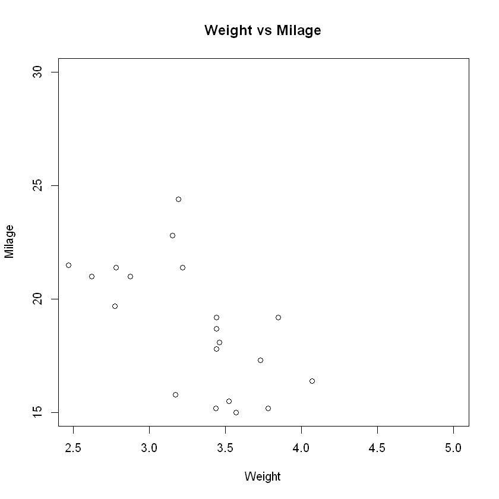

```r
plot(x = input$wt, y = input$mpg, xlab = "Weight", ylab = "Milage",
     xlim = c(2.5,5), ylim = c(15,30), main = "Weight vs Milage")
```

Para adicionar líneas y colores:

Para la recta de regresión $y=\beta_0+\beta_1 x+\epsilon$ usar : `lm(mpg~wt, data)`

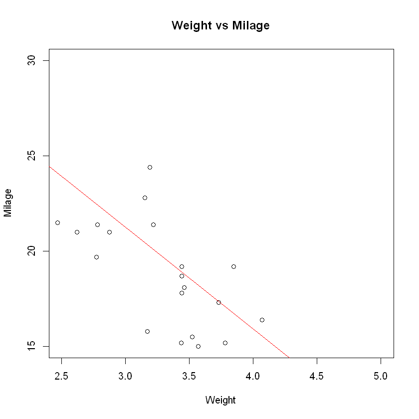

```r
plot(x = input$wt,y = input$mpg,  xlab = "Weight",   ylab = "Milage",   xlim = c(2.5,5),
     ylim = c(15,30),   main = "Weight vs Milage")

abline(lm(mpg~wt,data=input), col="red")
```

## Gráficos de dispersión múltiples

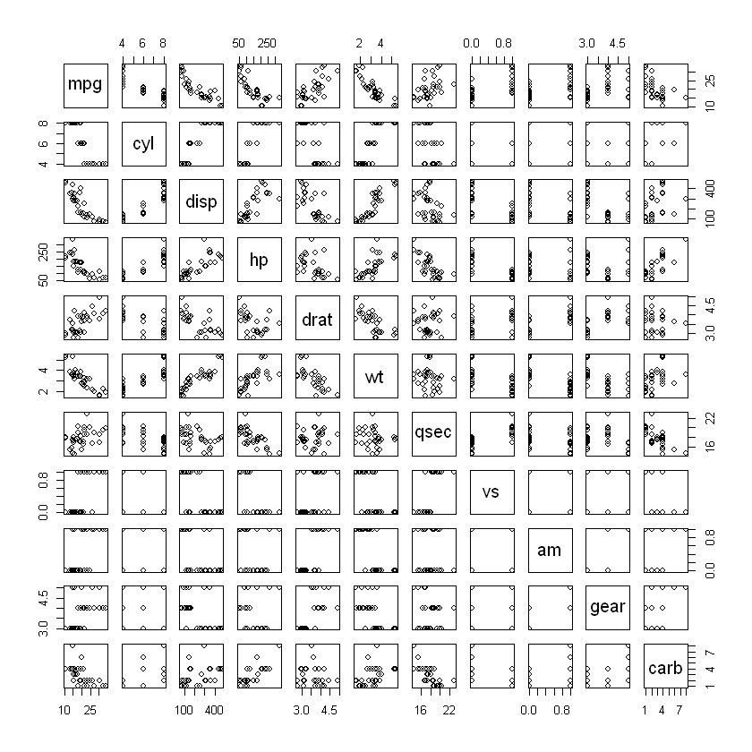

```r
pairs(mtcars)
```

# Boxplot

Recordemos que el comando **summary** nos muestra el valor de la media, la mediana, el mínimo, y el máximo de nuestro conjunto de datos. El diagrama de cajas o boxplot permite identificar visualmente todos estos valores y da información con respecto a la distribución de los valores de nuestro conjunto de datos.

Para hacer un diagrama de cajas usamos el comando **boxplot**:

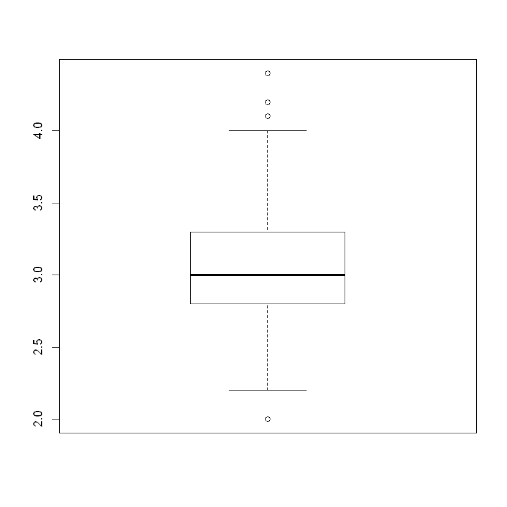

```r
z = iris[,"Sepal.Width"]
boxplot(z)
```

- La línea gruesa es la mediana.
- La parte inferior de la caja es el primer cuartil (1st Qu.), esto es, el valor que separa al primer 25% de los datos (luego de ordenarlos de menor a mayor).
- La mediana (corresponde al segundo cuartil) permite dividir al conjunto de datos en dos partes de modo tal que cada parte tendrá el 50% de los datos (luego de ordenar todo el conjunto de datos de menor a mayor).
- El tercer cuartil (3st Qu.) separa al 75% de los datos una vez ordenados de menor a mayor.
- La distancia que hay entre el primer y el tercer cuartil se conoce como rango intercuartílico (IQR) y permite tener una idea de la dispersión (acumulación) de los valores alrededor de la mediana, también, permite calcular el tamaño de los “bigotes” (aproximadamente 1.5 veces el IQR).
- Los valores que escapan a los “bigotes” se consideran valores extremos porque “aparentemente” no forman parte del grupo.

La función **par(mfrow = c(2,1))**, Divide la ventana de gráficos en dos filas y una columna:

```r
par(mfrow = c(2,1))
```

La función **par(mfrow = c(1,1))**, Regresa la ventana a su estado original

```r
par(mfrow = c(1,1))
```

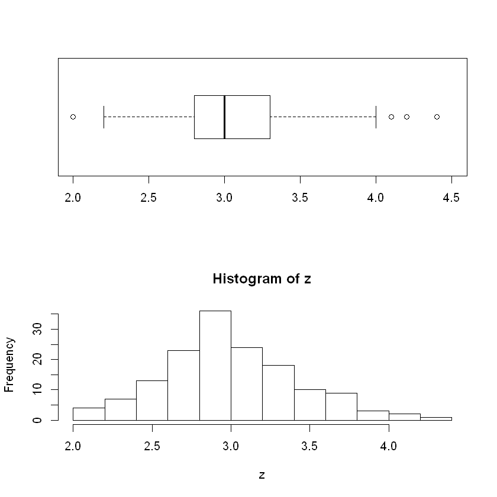

```r
par(mfrow = c(2,1))
boxplot(z, horizontal = TRUE, ylim = c(2, 4.5))
hist(z)
```

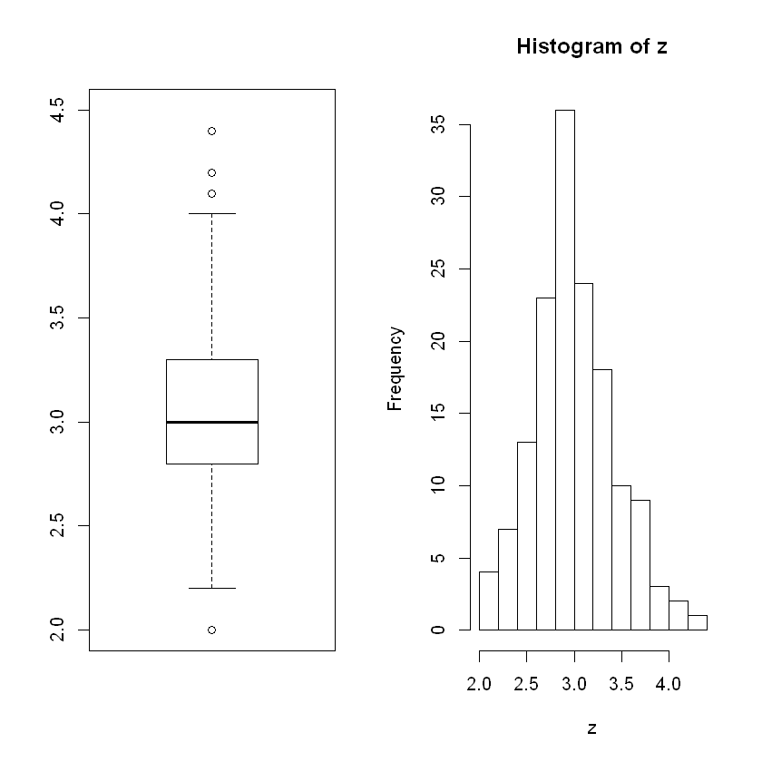

```r
par(mfrow = c(1,2))
boxplot(z, horizontal = F, ylim = c(2, 4.5))
hist(z)
```

Para dividir las cajas podemos usar el símbolo “~” que, en R, quiere decir “en función de”.

En nuestro caso será: variable en cuestión (Sepal.Length) ~ variable categórica (Species):

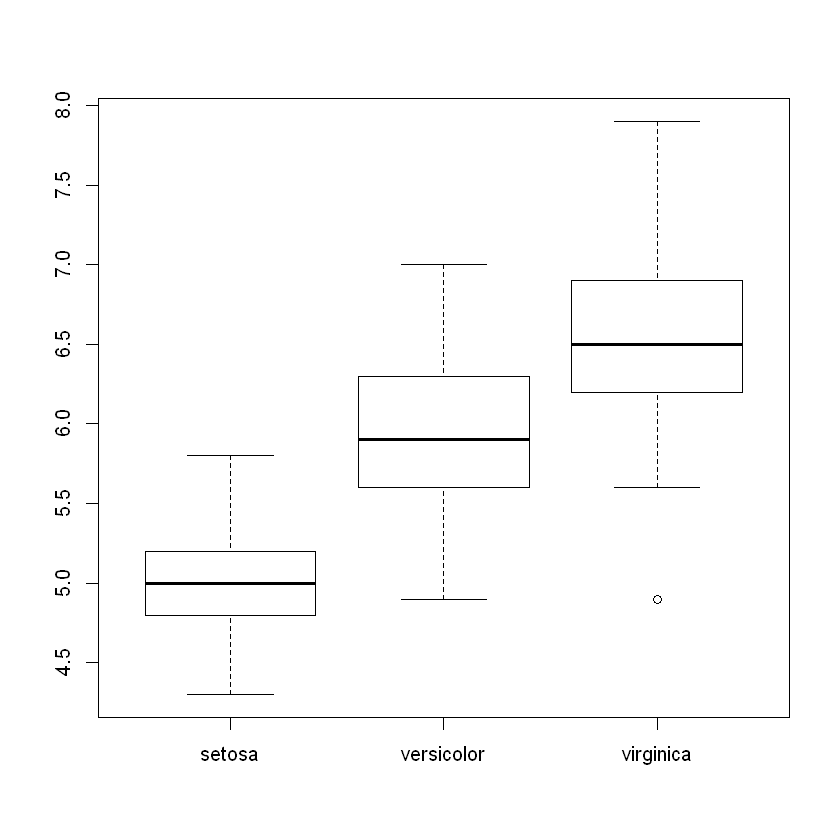

```r
boxplot(iris$Sepal.Length ~ iris$Species)
```

O en horizontal:

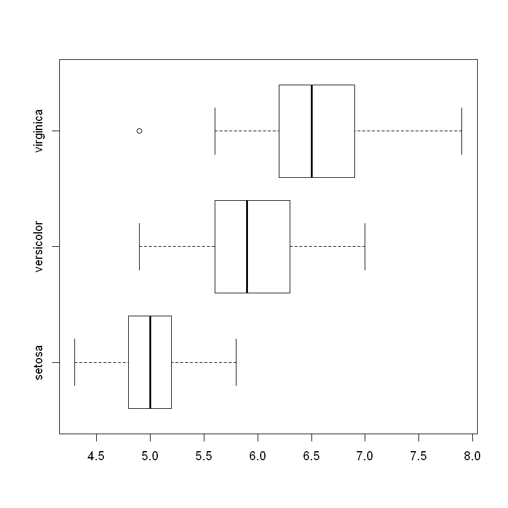

```r
boxplot(iris$Sepal.Length ~ iris$Species,
        horizontal = TRUE)
```

Para colorear las cajas podemos usar el argumento **col** o el argumento **border** para colorear únicamente el borde:

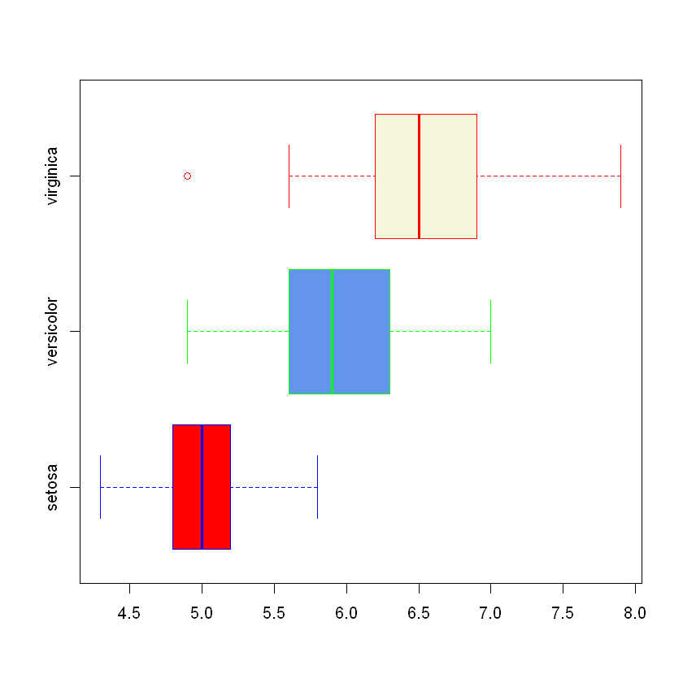

```r
boxplot(iris$Sepal.Length ~ iris$Species, horizontal = TRUE,
        border = c("blue", "green", "red"),
        col    = c("red","cornflowerblue","beige"))
```

# Pie charts

Los gráficos circulares o pie charts se crean con la función **pie(x, labels =)** donde x es un vector numérico no negativo que indica el área de cada corte y **labels=** anota un vector de caracteres de los nombres para los sectores

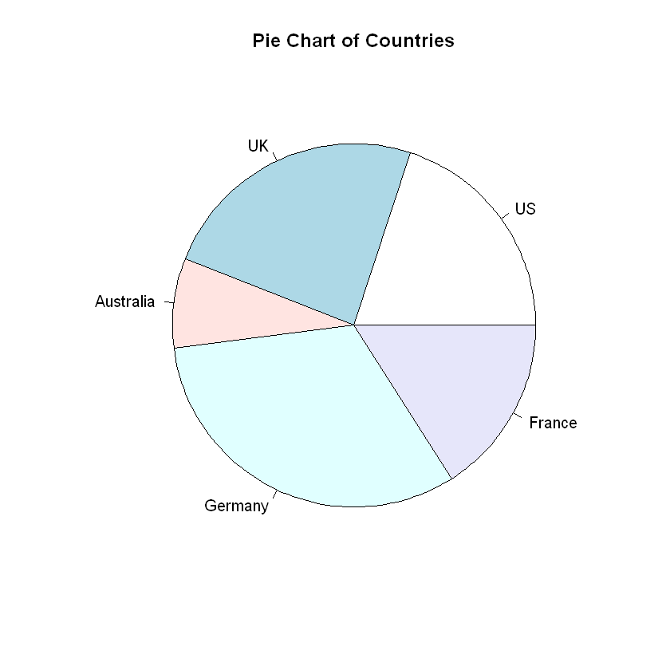

```r
slices = c(10, 12,4, 16, 8)
lbls = c("US", "UK", "Australia", "Germany", "France")
pie(slices, labels = lbls, main="Pie Chart of Countries")
```

Para incluir los porcentajes usamos **pct** y **%** y para colores en el gráfico usamos el argumento **col**:

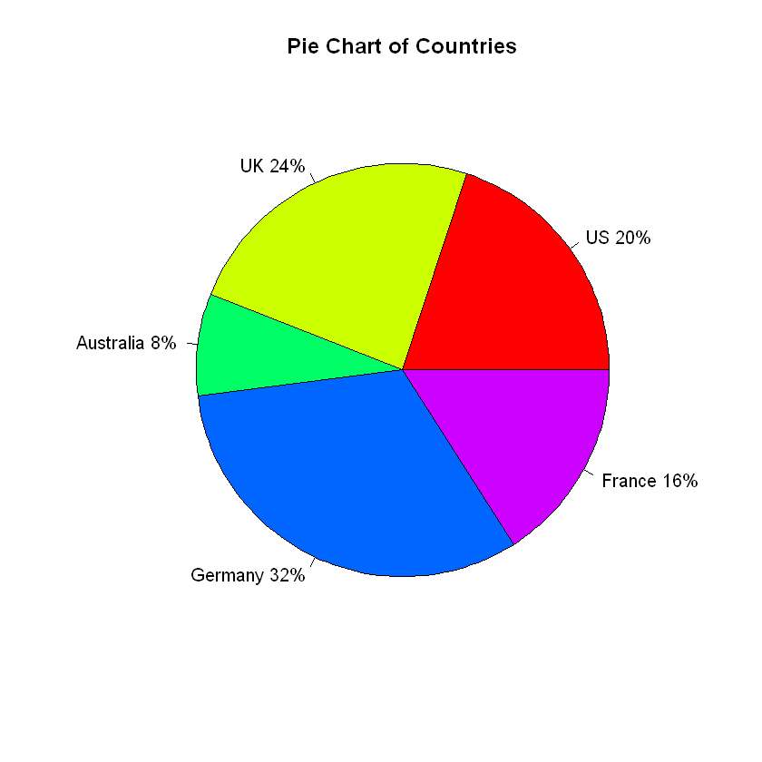

```r
slices = c(10, 12, 4, 16, 8)
lbls = c("US", "UK", "Australia", "Germany", "France")
pct = round(slices/sum(slices)*100)
lbls = paste(lbls, pct)
lbls = paste(lbls,"%",sep="")
pie(slices,labels = lbls, col=rainbow(length(lbls)),
  	main="Pie Chart of Countries")
```

# Taller en clase

Lectura de la base de datos de estaturas

```r
url   = "https://raw.githubusercontent.com/jfzeac/analisis_datos_r/master/NCD_RisC_eLife_2016_height_age18_countries.csv"
datos = read.csv(url)
head(datos)
```

| Country | ISO | Sex | Year.of.birth | Mean.height..cm. | Mean.height.lower.95..uncertainty.interval..cm. | Mean.height.upper.95..uncertainty.interval..cm. |
| --- | --- | --- | --- | --- | --- | --- |
| Afghanistan | AFG | Men | 1896 | 161.1641 | 154.4843 | 167.7540 |
| Afghanistan | AFG | Men | 1897 | 161.1963 | 154.5716 | 167.6596 |
| Afghanistan | AFG | Men | 1898 | 161.2283 | 154.7073 | 167.6026 |
| Afghanistan | AFG | Men | 1899 | 161.2607 | 154.8356 | 167.5281 |
| Afghanistan | AFG | Men | 1900 | 161.2931 | 154.9595 | 167.5081 |
| Afghanistan | AFG | Men | 1901 | 161.3255 | 155.0317 | 167.4745 |

Lectura de medidas antropometrícas escolares

```r
url2    = "https://raw.githubusercontent.com/jfzeac/analisis_datos_r/master/medidas_escolares.csv"
medidas = read.csv(url2)
head(medidas)
```

| ID | COD_CIUDAD | SEXO | EDA_DECI | PESO | ESTATURA | TALLA_SENT | HOM | CAD | BICON | VPUBICO | DGLANDULAM |
| --- | --- | --- | --- | --- | --- | --- | --- | --- | --- | --- | --- |
| ID1 | 2 | m | 4.425 | 23.0 | 122.7 | 66.8 | 73.4 | 58.9 | 19.0 | 0 | 0 |
| ID2 | 2 | m | 4.978 | 21.2 | 118.0 | 64.8 | 79.0 | 60.4 | 17.8 | 0 | 0 |
| ID3 | 2 | m | 4.978 | 24.7 | 119.1 | 65.9 | 72.3 | 66.7 | 20.5 | 0 | 0 |
| ID4 | 2 | m | 4.978 | 20.5 | 125.2 | 70.3 | 65.7 | 56.2 | 17.3 | 0 | 0 |
| ID5 | 2 | m | 4.984 | 22.2 | 122.6 | 67.3 | 69.6 | 59.8 | 19.1 | 0 | 0 |
| ID6 | 2 | m | 5.058 | 20.7 | 119.3 | 64.8 | 65.4 | 59.2 | 18.6 | 0 | 0 |

Es una encuesta balanceada:

```r
table(datos$Sex)
```

```
  Men Women
20200 20200
```

La función `subset(x, subset, select, drop = FALSE, ...)` permite segmentar la base de datos. Por ejemplo, podemos segmentar a las mujeres de Ecuador y requerir solamente las variables Country, Sex, Year.of.birth y Mean.height..cm.:

```r
estat_mujeres = subset(datos, Sex == "Women" &   Country == "Ecuador",
                        select = c(Country, Sex, Year.of.birth, Mean.height..cm.))
head(estat_mujeres)
```

|  | Country | Sex | Year.of.birth | Mean.height..cm. |
| --- | --- | --- | --- | --- |
| 25655 | Ecuador | Women | 1896 | 143.0014 |
| 25656 | Ecuador | Women | 1897 | 143.1721 |
| 25657 | Ecuador | Women | 1898 | 143.3430 |
| 25658 | Ecuador | Women | 1899 | 143.5140 |
| 25659 | Ecuador | Women | 1900 | 143.6846 |
| 25660 | Ecuador | Women | 1901 | 143.8554 |

Renombrar columnas:

```r
colnames(estat_mujeres) = c("País", "Sexo", "Año_Nacim", "Estatura")
colnames(estat_mujeres)
```

1. 'País'

2. 'Sexo'

3. 'Año_Nacim'

4. 'Estatura'

Plot de evolución de las estaturas de las mujeres ecuatorianas

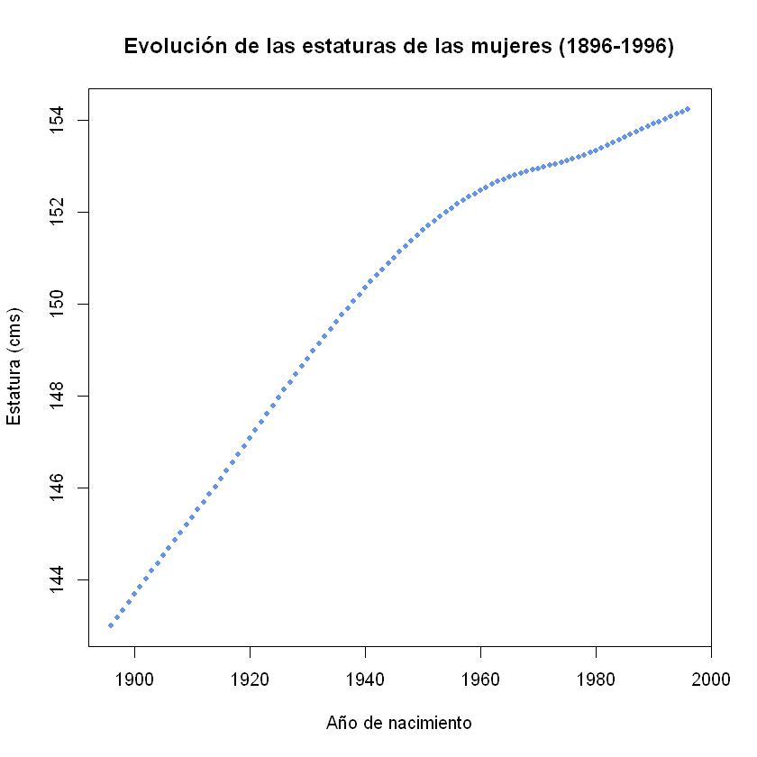

```r
plot(estat_mujeres$Año_Nacim, estat_mujeres$Estatura, pch = 20,
     xlab = "Año de nacimiento", ylab = "Estatura (cms)",
     main = "Evolución de las estaturas de las mujeres (1896-1996)",
     col  = "cornflowerblue" )
```

Para ver hombres y mujeres simultanemente

```r
estat = subset(datos, Country == "Ecuador",
                      select = c(Country, Sex, Year.of.birth, Mean.height..cm.))
colnames(estat) = c("País", "Sexo", "Año_Nacim", "Estatura")
head(estat)
```

|  | País | Sexo | Año_Nacim | Estatura |
| --- | --- | --- | --- | --- |
| 5455 | Ecuador | Men | 1896 | 155.6287 |
| 5456 | Ecuador | Men | 1897 | 155.7519 |
| 5457 | Ecuador | Men | 1898 | 155.8750 |
| 5458 | Ecuador | Men | 1899 | 155.9982 |
| 5459 | Ecuador | Men | 1900 | 156.1217 |
| 5460 | Ecuador | Men | 1901 | 156.2455 |

```r
table(estat$Sexo)
```

```
  Men Women
  101   101
```

Gráfico comparativo de la evolución de las estatutaras de los ecuatorianos.

1. Definimos el espacio donde se graficarán los datos con la función `plot()` y la opción `type = "n"` que implica no graficar los puntos.
2. Con la función `points()` añadimos los puntos sobre el área determinada en el punto 1.
3. Añadimos una leyenda al gráfico con la función `legend()`

Adicionalmente, **lty** define el tipo de lineas, **lwd** define el grosor de la linea y **cex** define el tamaño de la leyenda:

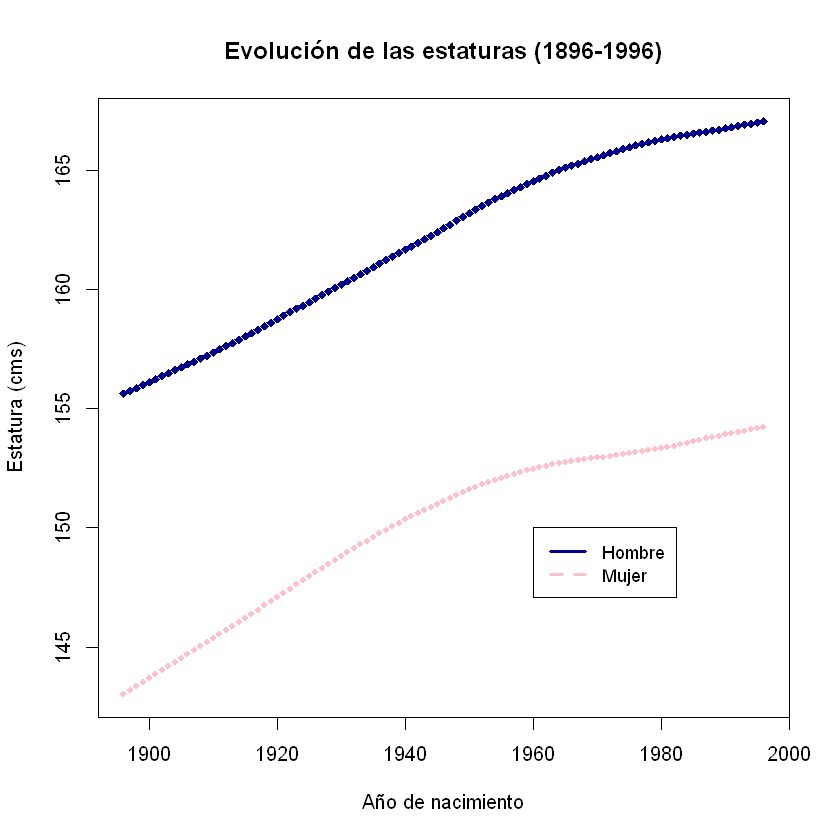

```r
plot(estat$Año_Nacim, estat$Estatura, pch = 20, xlab = "Año de nacimiento",
     ylab = "Estatura (cms)", main = "Evolución de las estaturas (1896-1996)",
     type = "n")

points(estat$Año_Nacim[estat$Sexo == "Men"], estat$Estatura[estat$Sexo == "Men"],
       col = "darkblue", pch = 18)

points(estat$Año_Nacim[estat$Sexo == "Women"], estat$Estatura[estat$Sexo == "Women"],
       col = "pink", pch = 20)

legend(x=1960,y=150,
       c("Hombre", "Mujer"),
       lty=c(1,2),
       lwd=c(2.5,2.5),
       col=c("darkblue","pink"),
       cex = 0.9)
```

# Diagrama de dispersión

Correlación del peso y la estatura + regresión lineal.

```r
cor(medidas$PESO, medidas$ESTATURA)
modelo = lm(ESTATURA ~ PESO, data = medidas)
```

0.898760236900132

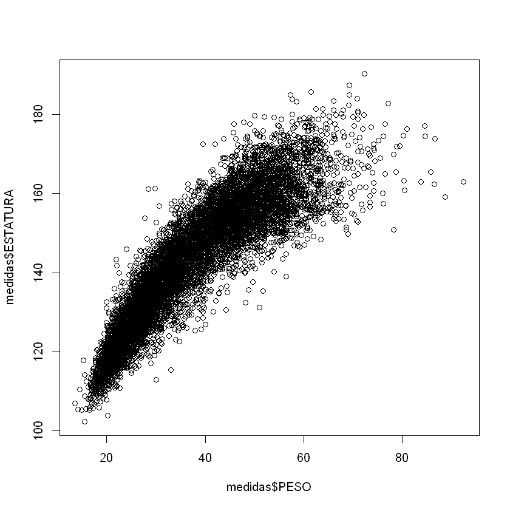

```r
plot(medidas$PESO, medidas$ESTATURA)
```

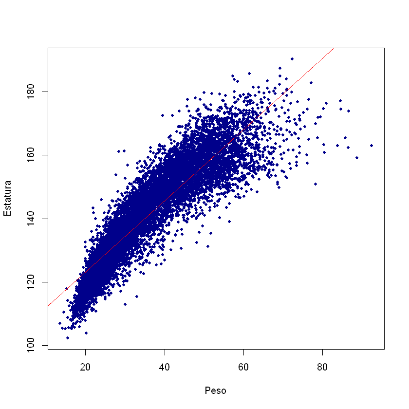

```r
plot(medidas$PESO, medidas$ESTATURA, xlab = "Peso", ylab = "Estatura", pch = 20,
     col = "darkblue")
abline(modelo, col = "red")
```

a. Graficar unos boxplot por género de las estaturas de los niños de 14 años

```r
table(medidas$EDA_DECI >= 14  & medidas$EDA_DECI < 15 )
```

```
FALSE  TRUE
 8563   976
```

```r
niños14 = subset(medidas, 14 <= EDA_DECI  & EDA_DECI < 15,
                 select = c(ID, SEXO, ESTATURA ))
head(niños14)
```

|  | ID | SEXO | ESTATURA |
| --- | --- | --- | --- |
| 6816 | ID6816 | f | 151.1 |
| 6817 | ID6817 | f | 151.7 |
| 6818 | ID6818 | f | 161.4 |
| 6819 | ID6819 | f | 153.0 |
| 6820 | ID6820 | f | 153.4 |
| 6821 | ID6821 | m | 173.4 |

Boxplot de todos los niños

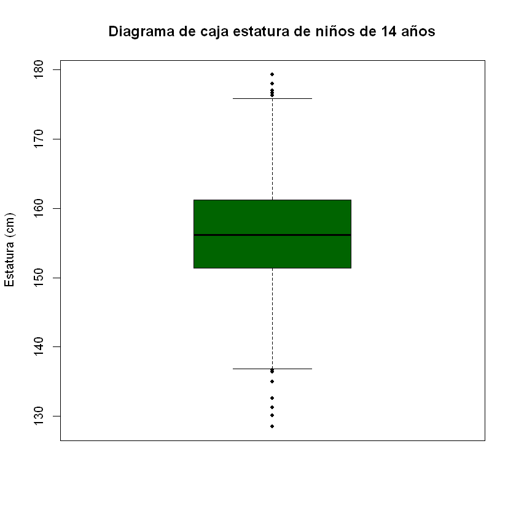

```r
boxplot(niños14$ESTATURA, col = "darkgreen", ylab = "Estatura (cm)",
        main = "Diagrama de caja estatura de niños de 14 años", pch = 20)
```

Boxplot por sexo

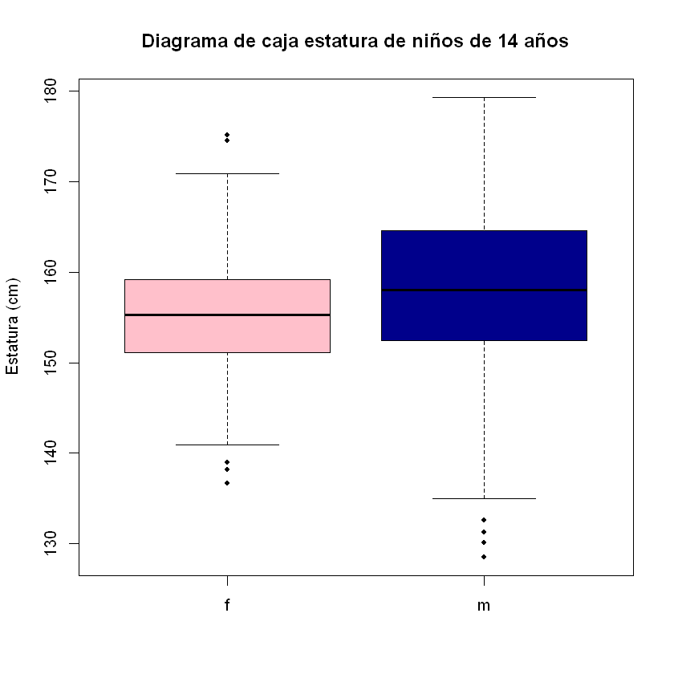

```r
boxplot( niños14$ESTATURA ~ niños14$SEXO ,
        col = c("pink", "darkblue"),
        ylab = "Estatura (cm)",
        main = "Diagrama de caja estatura de niños de 14 años",
        pch = 20)
```

# Diagrama de caja y jitter

Jitter hace referencia la inclusión de los individuos en el boxplot.

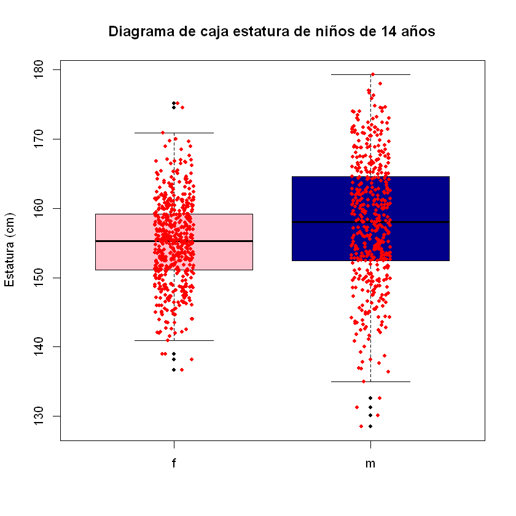

```r
boxplot(niños14$ESTATURA ~ niños14$SEXO , col = c("pink", "darkblue"),
        ylab = "Estatura (cm)",
        main = "Diagrama de caja estatura de niños de 14 años", pch = 20)

stripchart(niños14$ESTATURA ~ niños14$SEXO, vertical = TRUE,
           method = "jitter", add = TRUE, pch = 20, col = 'red')
```